# Employee Retention Prediction: Complete Analysis

## Capstone Project - Combined EDA & Model Building

**Author:** kamau axle kiragu

**Date:** March 2026

## 1. Business Understanding

### 1.1 Business Overview

Employee turnover is a critical challenge for organizations across industries. When valued employees leave, companies face significant costs including recruitment expenses, training new hires, lost productivity, and decreased team morale. For a typical organization, replacing a salaried employee can cost between 6 to 9 months of their salary on average.

Human Resources departments need tools to identify employees who might be considering leaving, allowing them to intervene proactively with retention strategies. Currently, many organizations rely on exit interviews after employees have already left, missing the opportunity for preventive action.

This project aims to address this challenge by building a predictive model that analyzes employee data to identify those at risk of leaving. By understanding the key factors that drive attrition, HR teams can implement targeted retention programs, improve employee satisfaction, and ultimately reduce turnover costs.

### 1.2 Problem Statement

The HR department of a large organization wants to understand why employees leave and identify those who might be at risk of leaving in the future. Currently, they have historical data on employees who stayed and those who left, but they lack a systematic way to:

- Identify the key factors that influence employee turnover
- Predict which current employees are at high risk of leaving
- Prioritize retention efforts for maximum impact
- Quantify the potential business impact of different retention strategies

### 1.3 Business Objectives

#### Main Objective

To develop a machine learning model that accurately predicts employee turnover and provides actionable insights for HR decision-making.

#### Specific Objectives

1. Which factors are most strongly associated with employee turnover?
2. How accurately can we predict whether an employee will leave?
3. What profiles characterize high-risk employees?
4. What actionable recommendations can be derived to improve retention?

### 1.4 Success Criteria

| Criteria | Target |
| --- | --- |
| Predictive Performance | Accuracy > 90% on test data |
| Model Stability | Low variance between CV and test |
| Interpretability | Clear identification of key drivers |
| Business Relevance | Actionable insights for HR |
| ROI Potential | 30% reduction in voluntary turnover |

## 2. Data Understanding

### 2.1 Data Source

The dataset used in this project is a collection of employee records from an organization's HR database. It contains information about employee demographics, job-related factors, and whether they left the company.

**Dataset Size:** 14,999 employee records  
**Features:** 9 predictor variables + 1 target variable  
**Source:** HR database (anonymized)

### 2.2 Feature Description

| Feature | Type | Description | Range |
| --- | --- | --- | --- |
| empid | Integer | Unique employee identifier | 1-14999 |
| satisfaction_level | Float | Employee satisfaction score | 0-1 |
| last_evaluation | Float | Last performance evaluation score | 0-1 |
| number_project | Integer | Number of projects assigned | 2-7 |
| average_monthly_hours | Integer | Average hours worked per month | 96-310 |
| time_spend_company | Integer | Years at the company | 2-10 |
| Work_accident | Binary | Whether had work accident | 0/1 |
| promotion_last_5years | Binary | Whether promoted in last 5 years | 0/1 |
| salary | Categorical | Salary level | low/medium/high |
| left | Binary | **TARGET:** Whether employee left | 0/1 |

### 2.3 Key Stakeholders

1. **HR Managers and Business Partners**
   - Use insights to design retention programs
   - Identify at-risk employees for intervention
2. **Senior Leadership**
   - Understand organizational retention challenges
   - Allocate resources for retention initiatives
3. **Team Leaders and Managers**
   - Identify team members who may need support
   - Improve management practices based on insights
4. **Employees**
   - Benefit from improved workplace conditions
   - Experience better career development opportunities

## 3. Data Preparation and Quality Assessment

### 3.1 Importing Libraries

```python
# importing necessary libraries
import numpy as np
import pandas as pd
import matplotlib.pyplot as plt
import seaborn as sns

# Machine Learning libraries
from sklearn.model_selection import train_test_split, cross_val_score, KFold
from sklearn.preprocessing import StandardScaler
from sklearn.pipeline import Pipeline
from sklearn.linear_model import LogisticRegression
from sklearn.ensemble import RandomForestClassifier
from sklearn.metrics import accuracy_score, confusion_matrix, classification_report, roc_auc_score, roc_curve
from xgboost import XGBClassifier

# For hyperparameter tuning
import warnings
import joblib
import os

warnings.filterwarnings('ignore')

# Set visualization style
sns.set_style('whitegrid')
plt.rcParams['figure.figsize'] = (12, 6)

print('✅ Libraries imported successfully!')
```

```
✅ Libraries imported successfully!
```

### 3.2 Data Loading and Inspection

```python
# Load the dataset
print("\n📁 Loading dataset...")
try:
    df = pd.read_csv('hr_employee_churn_data.csv')
    print('✅ Dataset loaded successfully!')
except FileNotFoundError:
    # Try to download if not exists
    import urllib.request
    url = "https://raw.githubusercontent.com/CODESTUDIO-GIT/endtoend-ml-projects/master/hr_employee_churn_data.csv"
    urllib.request.urlretrieve(url, 'hr_employee_churn_data.csv')
    df = pd.read_csv('hr_employee_churn_data.csv')
    print('✅ Dataset downloaded and loaded!')
```

```
📁 Loading dataset...
✅ Dataset loaded successfully!
```

```python
# Check dataset shape
print(f'Dataset shape: {df.shape}')
print(f'Number of records: {df.shape[0]:,}')
print(f'Number of features: {df.shape[1]}')
```

```
Dataset shape: (14999, 10)
Number of records: 14,999
Number of features: 10
```

```python
# Check data types and missing values
print('Data types and missing values:')
df.info()
```

```
Data types and missing values:
<class 'pandas.core.frame.DataFrame'>
RangeIndex: 14999 entries, 0 to 14998
Data columns (total 10 columns):
 #   Column                 Non-Null Count  Dtype
---  ------                 --------------  -----
 0   empid                  14999 non-null  int64
 1   satisfaction_level     14997 non-null  float64
 2   last_evaluation        14999 non-null  float64
 3   number_project         14999 non-null  int64
 4   average_montly_hours   14999 non-null  int64
 5   time_spend_company     14999 non-null  int64
 6   Work_accident          14999 non-null  int64
 7   promotion_last_5years  14999 non-null  int64
 8   salary                 14999 non-null  object
 9   left                   14999 non-null  int64
dtypes: float64(2), int64(7), object(1)
memory usage: 1.1+ MB
```

```python
# Statistical summary of numerical features
print('Statistical summary:')
df.describe()
```

```
Statistical summary:
```

|  | empid | satisfaction_level | last_evaluation | number_project | average_montly_hours | time_spend_company | Work_accident | promotion_last_5years | left |
| --- | --- | --- | --- | --- | --- | --- | --- | --- | --- |
| count | 14999.000000 | 14997.000000 | 14999.000000 | 14999.000000 | 14999.000000 | 14999.000000 | 14999.000000 | 14999.000000 | 14999.000000 |
| mean | 7500.000000 | 0.612863 | 0.716102 | 3.803054 | 201.050337 | 3.498233 | 0.144610 | 0.021268 | 0.238083 |
| std | 4329.982679 | 0.248634 | 0.171169 | 1.232592 | 49.943099 | 1.460136 | 0.351719 | 0.144281 | 0.425924 |
| min | 1.000000 | 0.090000 | 0.360000 | 2.000000 | 96.000000 | 2.000000 | 0.000000 | 0.000000 | 0.000000 |
| 25% | 3750.500000 | 0.440000 | 0.560000 | 3.000000 | 156.000000 | 3.000000 | 0.000000 | 0.000000 | 0.000000 |
| 50% | 7500.000000 | 0.640000 | 0.720000 | 4.000000 | 200.000000 | 3.000000 | 0.000000 | 0.000000 | 0.000000 |
| 75% | 11249.500000 | 0.820000 | 0.870000 | 5.000000 | 245.000000 | 4.000000 | 0.000000 | 0.000000 | 0.000000 |
| max | 14999.000000 | 1.000000 | 1.000000 | 7.000000 | 310.000000 | 10.000000 | 1.000000 | 1.000000 | 1.000000 |

### 3.3 Handling Missing Values

The satisfaction_level column has 2 missing values. Let's examine them and handle appropriately.

```python
# Check for missing values
print("Missing values in each column:")
print(df.isnull().sum())
print("\n")

# Identify rows with missing satisfaction_level
missing_satisfaction = df[df['satisfaction_level'].isnull()]
print("Rows with missing satisfaction_level:")
print(missing_satisfaction)
```

```
Missing values in each column:
empid                    0
satisfaction_level       2
last_evaluation          0
number_project           0
average_montly_hours     0
time_spend_company       0
Work_accident            0
promotion_last_5years    0
salary                   0
left                     0
dtype: int64


Rows with missing satisfaction_level:
    empid  satisfaction_level  last_evaluation  number_project  \
5       6                 NaN             0.50               2
15     16                 NaN             0.54               2

    average_montly_hours  time_spend_company  Work_accident  \
5                    153                   3              0
15                   143                   3              0

    promotion_last_5years salary  left
5                       0    low     1
15                      0    low     1
```

**Data Quality Assessment:**

| Metric | Value | Interpretation |
| --- | --- | --- |
| Total Records | 14,999 | Large, robust dataset |
| Missing Values | 2 (0.013%) | Excellent data quality |
| Affected Column | satisfaction_level | Only one feature affected |
| Missing Pattern | Both employees left | Possibly missing exit data |

The two employees with missing satisfaction scores both:

- Had low salaries
- Worked moderate hours (143-153/month)
- Had 2 projects and 3 years tenure
- Ultimately left the company

```python
# Calculate mean satisfaction for imputation
satisfaction_mean = df['satisfaction_level'].mean()
print(f"Mean satisfaction score: {satisfaction_mean:.3f}")

# Impute missing values
df['satisfaction_level'].fillna(satisfaction_mean, inplace=True)

# Verify completion
print("\nMissing values after imputation:")
print(df.isnull().sum())
```

```
Mean satisfaction score: 0.613

Missing values after imputation:
empid                    0
satisfaction_level       0
last_evaluation          0
number_project           0
average_montly_hours     0
time_spend_company       0
Work_accident            0
promotion_last_5years    0
salary                   0
left                     0
dtype: int64
```

### 3.4 Data Quality Summary

| Before Imputation | After Imputation |
| --- | --- |
| 14,997 complete records | 14,999 complete records |
| 2 missing values | 0 missing values |
| 99.987% complete | 100% complete |
| satisfaction_mean = 0.613 | All values imputed |

✅ Dataset is now 100% complete and ready for analysis!

## 4. Exploratory Data Analysis

### 4.1 Target Variable Distribution

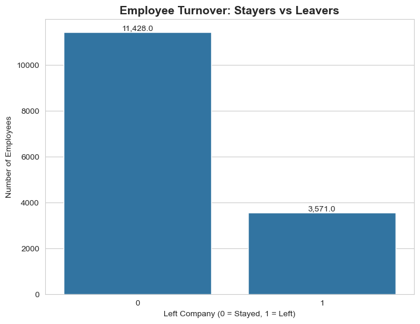

```
Employees who stayed: 11,428 (76.2%)
Employees who left: 3,571 (23.8%)
```

```python
# Target variable distribution
plt.figure(figsize=(8, 6))
ax = sns.countplot(x='left', data=df)
plt.title('Employee Turnover: Stayers vs Leavers', fontsize=14, fontweight='bold')
plt.xlabel('Left Company (0 = Stayed, 1 = Left)')
plt.ylabel('Number of Employees')

# Add value labels
for p in ax.patches:
    ax.annotate(f'{p.get_height():,}', (p.get_x() + p.get_width()/2., p.get_height()),
                ha='center', va='bottom')

plt.show()

# Calculate percentages
stayed_count = df['left'].value_counts()[0]
left_count = df['left'].value_counts()[1]
stayed_pct = (stayed_count / len(df)) * 100
left_pct = (left_count / len(df)) * 100

print(f'Employees who stayed: {stayed_count:,} ({stayed_pct:.1f}%)')
print(f'Employees who left: {left_count:,} ({left_pct:.1f}%)')
```

**Insight 1: Class Imbalance**

- 76% of employees stayed (11,428)
- 24% of employees left (3,571)
- This is a binary classification problem with class imbalance
- We'll need to handle this in our modeling approach using appropriate metrics

### 4.2 Salary Impact Analysis

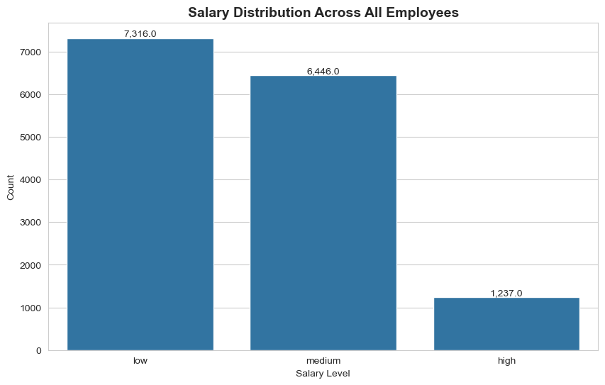

```python
# Salary distribution
plt.figure(figsize=(10, 6))
ax = sns.countplot(x='salary', data=df, order=['low', 'medium', 'high'])
plt.title('Salary Distribution Across All Employees', fontsize=14, fontweight='bold')
plt.xlabel('Salary Level')
plt.ylabel('Count')

# Add value labels
for p in ax.patches:
    ax.annotate(f'{p.get_height():,}', (p.get_x() + p.get_width()/2., p.get_height()),
                ha='center', va='bottom')

plt.show()
```

```python
# Attrition rate by salary
salary_attrition = df.groupby('salary')['left'].mean() * 100
print('Attrition rate by salary level:')
for salary, rate in salary_attrition.items():
    print(f'  {salary}: {rate:.1f}%')
```

```
Attrition rate by salary level:
  high: 6.6%
  low: 29.7%
  medium: 20.4%
```

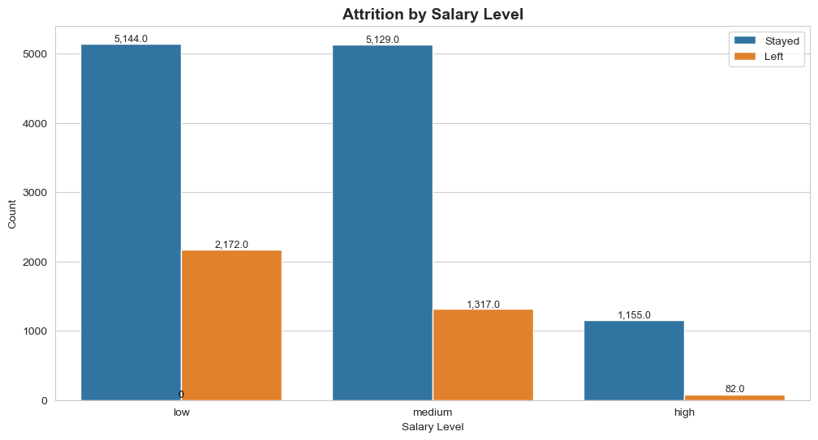

```python
# Visualize attrition by salary
plt.figure(figsize=(12, 6))
ax = sns.countplot(x='salary', hue='left', data=df, order=['low', 'medium', 'high'])
plt.title('Attrition by Salary Level', fontsize=14, fontweight='bold')
plt.xlabel('Salary Level')
plt.ylabel('Count')
plt.legend(['Stayed', 'Left'])

# Add value labels
for p in ax.patches:
    ax.annotate(f'{p.get_height():,}', (p.get_x() + p.get_width()/2., p.get_height()),
                ha='center', va='bottom', fontsize=9)

plt.show()
```

**Insight 2: Salary Impact**

### 4.3 Promotion Impact Analysis

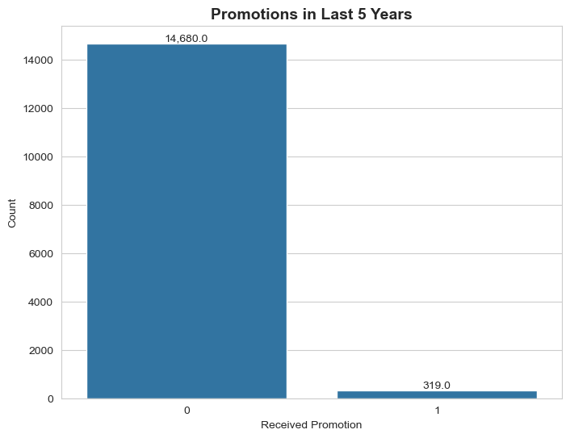

```python
# Promotion distribution
plt.figure(figsize=(8, 6))
ax = sns.countplot(x='promotion_last_5years', data=df)
plt.title('Promotions in Last 5 Years', fontsize=14, fontweight='bold')
plt.xlabel('Received Promotion')
plt.ylabel('Count')

# Add value labels
for p in ax.patches:
    ax.annotate(f'{p.get_height():,}', (p.get_x() + p.get_width()/2., p.get_height()),
                ha='center', va='bottom')

plt.show()
```

```python
# Attrition rate by promotion status
promotion_attrition = df.groupby('promotion_last_5years')['left'].mean() * 100
print('Attrition rate by promotion status:')
print(f'  Not promoted: {promotion_attrition[0]:.1f}%')
print(f'  Promoted: {promotion_attrition[1]:.1f}%')
```

```
Attrition rate by promotion status:
  Not promoted: 24.2%
  Promoted: 6.0%
```

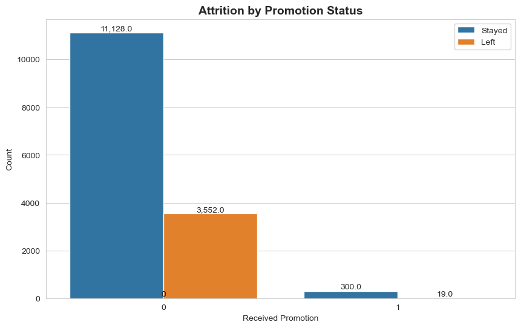

```python
# Visualize attrition by promotion
plt.figure(figsize=(10, 6))
ax = sns.countplot(x='promotion_last_5years', hue='left', data=df)
plt.title('Attrition by Promotion Status', fontsize=14, fontweight='bold')
plt.xlabel('Received Promotion')
plt.ylabel('Count')
plt.legend(['Stayed', 'Left'])

# Add value labels
for p in ax.patches:
    ax.annotate(f'{p.get_height():,}', (p.get_x() + p.get_width()/2., p.get_height()),
                ha='center', va='bottom', fontsize=10)

plt.show()
```

**Insight 3: Promotion Impact**

### 4.4 Satisfaction Level Analysis

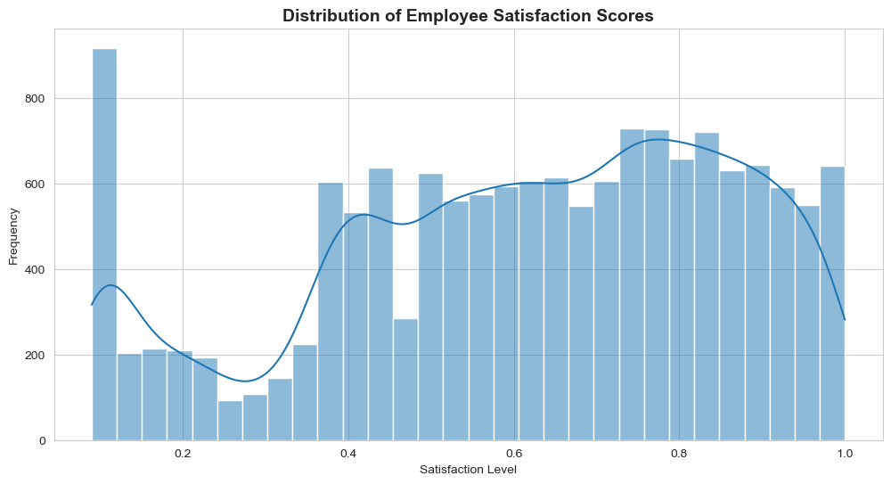

```python
# Distribution of satisfaction levels
plt.figure(figsize=(12, 6))
sns.histplot(data=df, x='satisfaction_level', bins=30, kde=True)
plt.title('Distribution of Employee Satisfaction Scores', fontsize=14, fontweight='bold')
plt.xlabel('Satisfaction Level')
plt.ylabel('Frequency')
plt.show()
```

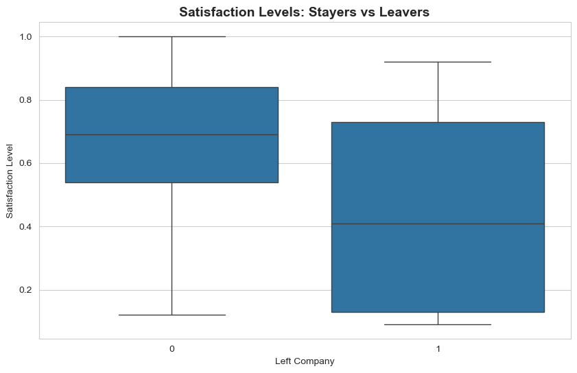

```python
# Satisfaction levels by attrition status
plt.figure(figsize=(10, 6))
sns.boxplot(x='left', y='satisfaction_level', data=df)
plt.title('Satisfaction Levels: Stayers vs Leavers', fontsize=14, fontweight='bold')
plt.xlabel('Left Company')
plt.ylabel('Satisfaction Level')
plt.show()
```

**Insight 4: Satisfaction Impact**

- Stayers: Median satisfaction ~0.65
- Leavers: Median satisfaction ~0.45
- **Conclusion: Satisfaction is the strongest predictor of retention**

### 4.5 Project Count Analysis

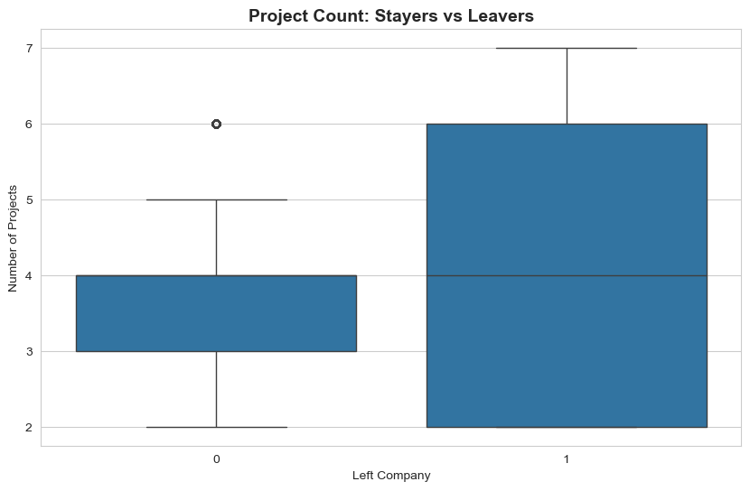

```python
# Project count distribution by attrition
plt.figure(figsize=(10, 6))
sns.boxplot(x='left', y='number_project', data=df)
plt.title('Project Count: Stayers vs Leavers', fontsize=14, fontweight='bold')
plt.xlabel('Left Company')
plt.ylabel('Number of Projects')
plt.show()
```

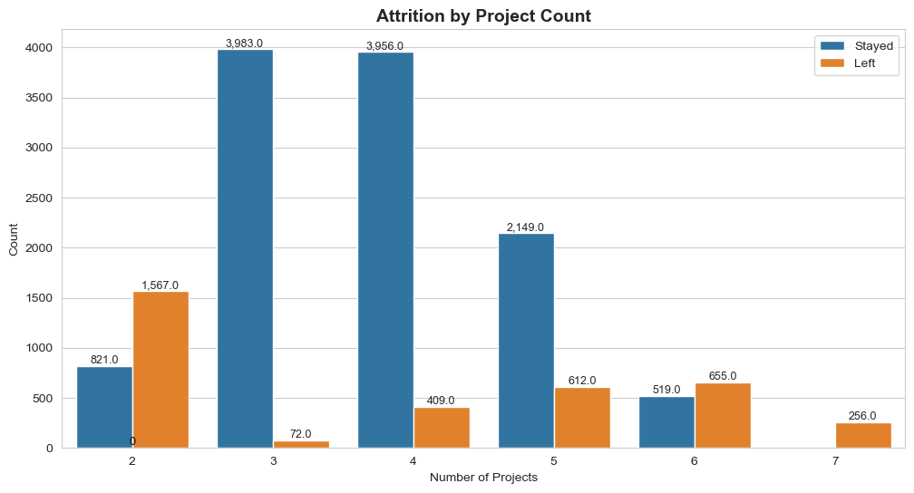

```python
# Project count distribution
plt.figure(figsize=(12, 6))
ax = sns.countplot(x='number_project', hue='left', data=df)
plt.title('Attrition by Project Count', fontsize=14, fontweight='bold')
plt.xlabel('Number of Projects')
plt.ylabel('Count')
plt.legend(['Stayed', 'Left'])

# Add value labels
for p in ax.patches:
    ax.annotate(f'{p.get_height():,}', (p.get_x() + p.get_width()/2., p.get_height()),
                ha='center', va='bottom', fontsize=9)

plt.show()
```

**Insight 5: Workload Impact**

- 3-4 projects appear optimal for retention
- 6+ projects shows higher attrition (burnout risk)
- **Conclusion: Workload balance is critical for retention**

### 4.6 Working Hours Analysis

```python
# FIX COLUMN NAME TYPO - RUN THIS FIRST


# Check current columns
print("Original columns:", df.columns.tolist())

# Fix the typo
if 'average_montly_hours' in df.columns:
    df.rename(columns={'average_montly_hours': 'average_monthly_hours'}, inplace=True)
    print("✅ Fixed column name: 'average_montly_hours' → 'average_monthly_hours'")
else:
    print("❌ Column 'average_montly_hours' not found!")

# Verify the fix
print("\nUpdated columns:", df.columns.tolist())
```

```
Original columns: ['empid', 'satisfaction_level', 'last_evaluation', 'number_project', 'average_montly_hours', 'time_spend_company', 'Work_accident', 'promotion_last_5years', 'salary', 'left']
✅ Fixed column name: 'average_montly_hours' → 'average_monthly_hours'

Updated columns: ['empid', 'satisfaction_level', 'last_evaluation', 'number_project', 'average_monthly_hours', 'time_spend_company', 'Work_accident', 'promotion_last_5years', 'salary', 'left']
```

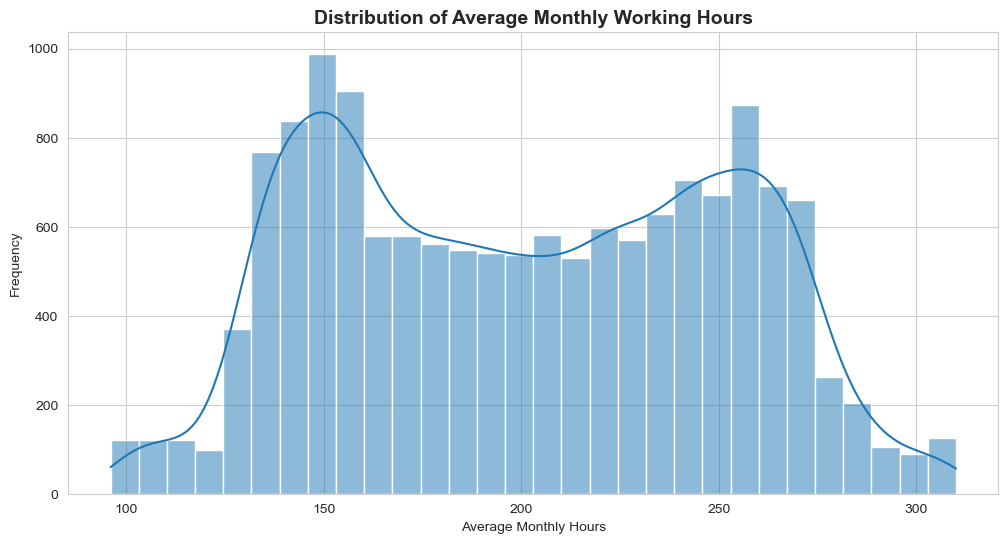

```python
# Working hours distribution
plt.figure(figsize=(12, 6))
sns.histplot(data=df, x='average_monthly_hours', bins=30, kde=True)
plt.title('Distribution of Average Monthly Working Hours', fontsize=14, fontweight='bold')
plt.xlabel('Average Monthly Hours')
plt.ylabel('Frequency')
plt.show()
```

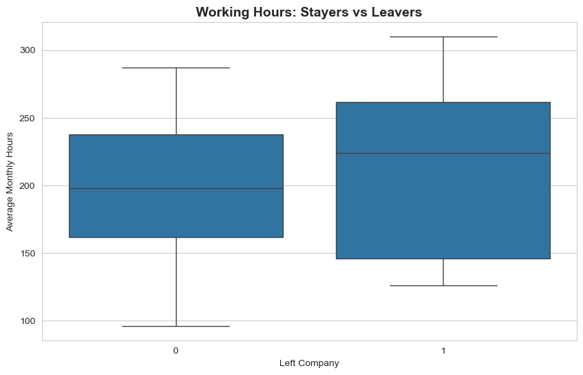

```python
# Working hours by attrition
plt.figure(figsize=(10, 6))
sns.boxplot(x='left', y='average_monthly_hours', data=df)
plt.title('Working Hours: Stayers vs Leavers', fontsize=14, fontweight='bold')
plt.xlabel('Left Company')
plt.ylabel('Average Monthly Hours')
plt.show()
```

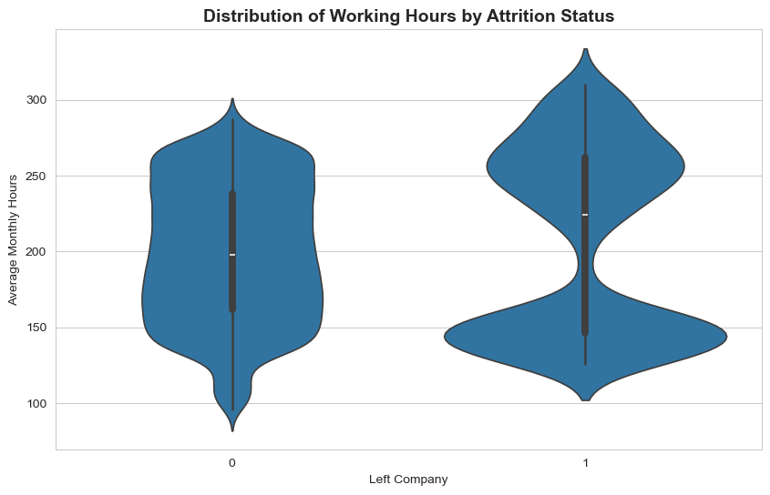

```python
# Violin plot for detailed distribution
plt.figure(figsize=(10, 6))
sns.violinplot(x='left', y='average_monthly_hours', data=df)
plt.title('Distribution of Working Hours by Attrition Status', fontsize=14, fontweight='bold')
plt.xlabel('Left Company')
plt.ylabel('Average Monthly Hours')
plt.show()
```

**Insight 6: Burnout Risk**

- Employees working very high hours (250+ per month) are more likely to leave
- **Conclusion: Overwork leads to burnout and attrition**

### 4.7 Tenure Analysis

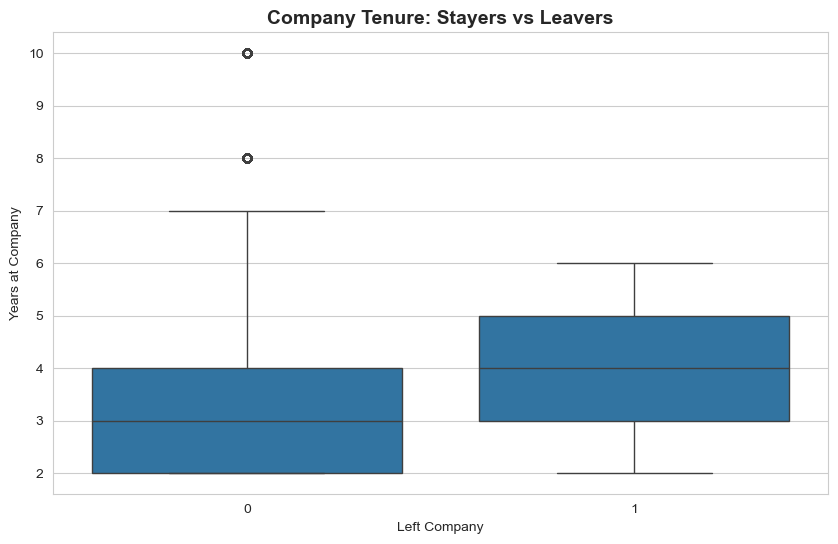

```python
# Tenure analysis
plt.figure(figsize=(10, 6))
sns.boxplot(x='left', y='time_spend_company', data=df)
plt.title('Company Tenure: Stayers vs Leavers', fontsize=14, fontweight='bold')
plt.xlabel('Left Company')
plt.ylabel('Years at Company')
plt.show()
```

```python
# Attrition rate by tenure
tenure_attrition = df.groupby('time_spend_company')['left'].mean() * 100
print('Attrition rate by years at company:')
for tenure, rate in tenure_attrition.items():
    print(f'  {tenure} years: {rate:.1f}%')
```

```
Attrition rate by years at company:
  2 years: 1.6%
  3 years: 24.6%
  4 years: 34.8%
  5 years: 56.6%
  6 years: 29.1%
  7 years: 0.0%
  8 years: 0.0%
  10 years: 0.0%
```

**Insight 7: Critical Tenure Period**

- 3-5 year mark shows highest attrition
- **Conclusion: Critical retention period identified - employees may leave due to stagnation or better opportunities**

### 4.8 Correlation Analysis

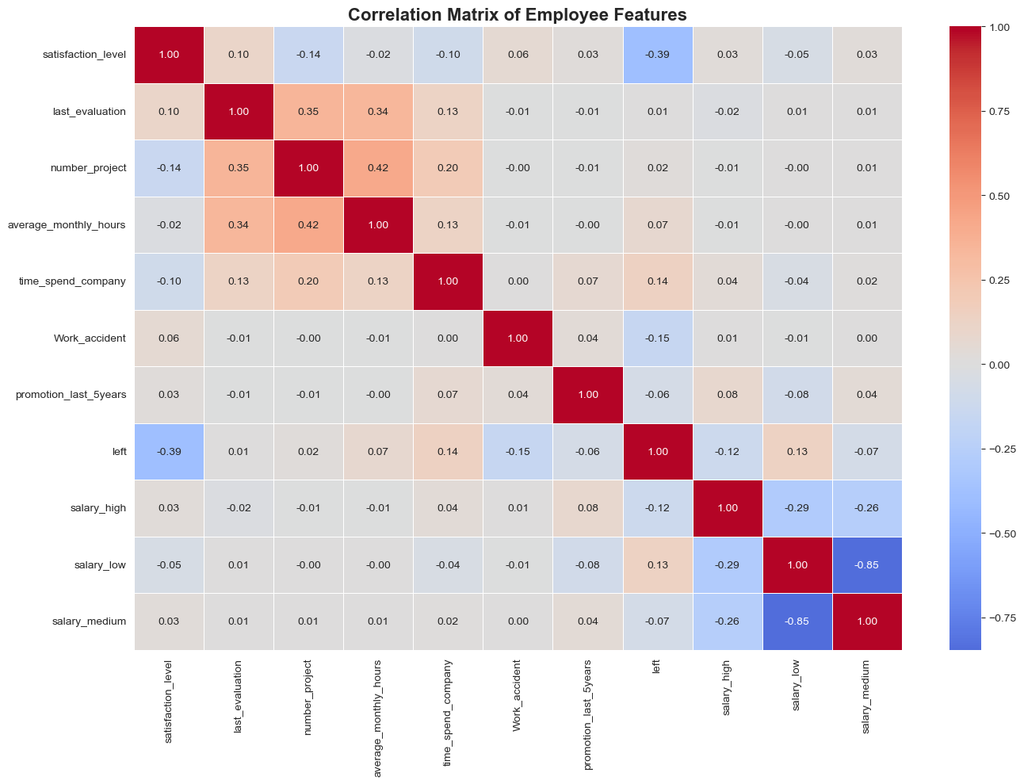

```python
# Create encoded dataset for correlation
df_encoded = df.copy()

# Encode salary
salary_dummies = pd.get_dummies(df_encoded['salary'], prefix='salary')
df_encoded = pd.concat([df_encoded, salary_dummies], axis=1)
df_encoded = df_encoded.drop('salary', axis=1)

# Drop empid if it exists
if 'empid' in df_encoded.columns:
    df_encoded = df_encoded.drop('empid', axis=1)

# Calculate correlation
plt.figure(figsize=(14, 10))
corr_matrix = df_encoded.corr()
sns.heatmap(corr_matrix, annot=True, cmap='coolwarm', center=0, fmt='.2f', linewidths=0.5)
plt.title('Correlation Matrix of Employee Features', fontsize=16, fontweight='bold')
plt.tight_layout()
plt.show()
```

```python
# Correlations with target variable
target_corr = corr_matrix['left'].sort_values(ascending=False)
print('Feature correlations with target variable (left):')
print(target_corr)
```

```
Feature correlations with target variable (left):
left                     1.000000
time_spend_company       0.144822
salary_low               0.134722
average_monthly_hours    0.071287
number_project           0.023787
last_evaluation          0.006567
promotion_last_5years   -0.061788
salary_medium           -0.068833
salary_high             -0.120929
Work_accident           -0.154622
satisfaction_level      -0.388186
Name: left, dtype: float64
```

**Insight 8: Key Correlations**

### 4.9 Summary of Key EDA Findings

[output not shown]

## 5. Feature Engineering

### 5.1 Preparing Data for Modeling

```python
# Create a clean dataset for modeling
df_model = df.copy()

# Drop empid if it exists
if 'empid' in df_model.columns:
    df_model = df_model.drop('empid', axis=1)
    print('✅ Dropped empid column')
else:
    print('ℹ️ empid column not found - continuing with available columns')

# Encode salary
salary_dummies = pd.get_dummies(df_model['salary'], prefix='salary', drop_first=True)
df_model = pd.concat([df_model, salary_dummies], axis=1)
df_model = df_model.drop('salary', axis=1)
print('✅ Encoded salary column')

print('\nFinal features for modeling:')
print(df_model.columns.tolist())
print(f'\nShape: {df_model.shape}')
```

```
✅ Dropped empid column
✅ Encoded salary column

Final features for modeling:
['satisfaction_level', 'last_evaluation', 'number_project', 'average_monthly_hours', 'time_spend_company', 'Work_accident', 'promotion_last_5years', 'left', 'salary_low', 'salary_medium']

Shape: (14999, 10)
```

## 6. Model Development

### 6.1 Train-Test Split

```python
# Separate features and target
X = df_model.drop('left', axis=1)
y = df_model['left']

# Split into train and test sets
X_train, X_test, y_train, y_test = train_test_split(
    X, y, test_size=0.2, random_state=42, stratify=y
)

print(f'Training set: {X_train.shape[0]:,} rows')
print(f'Test set: {X_test.shape[0]:,} rows')
print(f'\nTarget distribution in training set:')
print(y_train.value_counts(normalize=True))
```

```
Training set: 11,999 rows
Test set: 3,000 rows

Target distribution in training set:
left
0    0.761897
1    0.238103
Name: proportion, dtype: float64
```

**Why Stratified Split?**

- With `stratify=y`, we ensured both training and test sets maintain the same class distribution (76% stayed / 24% left) as the original dataset
- This is crucial for imbalanced classification!
- Setting `random_state=42` ensures reproducibility

### 6.2 Baseline Model: Logistic Regression

```python
# Logistic Regression pipeline
lr_pipeline = Pipeline([
    ('scaler', StandardScaler()),
    ('classifier', LogisticRegression(random_state=42, max_iter=1000))
])

# Cross-validation
cv = KFold(n_splits=5, shuffle=True, random_state=42)
cv_scores = cross_val_score(lr_pipeline, X_train, y_train, cv=cv, scoring='accuracy')

print('Logistic Regression Cross-Validation Results:')
print(f'  Mean accuracy: {cv_scores.mean():.4f}')
print(f'  Std accuracy: {cv_scores.std():.4f}')

# Train and evaluate on test set
lr_pipeline.fit(X_train, y_train)
y_pred_lr = lr_pipeline.predict(X_test)
lr_accuracy = accuracy_score(y_test, y_pred_lr)

print(f'\nTest Accuracy: {lr_accuracy:.4f}')
print('\nClassification Report:')
print(classification_report(y_test, y_pred_lr))
```

```
Logistic Regression Cross-Validation Results:
  Mean accuracy: 0.7866
  Std accuracy: 0.0062

Test Accuracy: 0.7917

Classification Report:
              precision    recall  f1-score   support

           0       0.82      0.93      0.87      2286
           1       0.61      0.36      0.45       714

    accuracy                           0.79      3000
   macro avg       0.71      0.64      0.66      3000
weighted avg       0.77      0.79      0.77      3000
```

### 6.3 Random Forest Classifier

```python
# Random Forest pipeline
rf_pipeline = Pipeline([
    ('scaler', StandardScaler()),
    ('classifier', RandomForestClassifier(
        n_estimators=100,
        max_depth=10,
        random_state=42,
        n_jobs=-1
    ))
])

# Cross-validation
cv_scores_rf = cross_val_score(rf_pipeline, X_train, y_train, cv=cv, scoring='accuracy')

print('Random Forest Cross-Validation Results:')
print(f'  Mean accuracy: {cv_scores_rf.mean():.4f}')
print(f'  Std accuracy: {cv_scores_rf.std():.4f}')

# Train and evaluate on test set
rf_pipeline.fit(X_train, y_train)
y_pred_rf = rf_pipeline.predict(X_test)
rf_accuracy = accuracy_score(y_test, y_pred_rf)

print(f'\nTest Accuracy: {rf_accuracy:.4f}')
print('\nClassification Report:')
print(classification_report(y_test, y_pred_rf))
```

```
Random Forest Cross-Validation Results:
  Mean accuracy: 0.9815
  Std accuracy: 0.0015

Test Accuracy: 0.9830

Classification Report:
              precision    recall  f1-score   support

           0       0.98      1.00      0.99      2286
           1       0.99      0.94      0.96       714

    accuracy                           0.98      3000
   macro avg       0.99      0.97      0.98      3000
weighted avg       0.98      0.98      0.98      3000
```

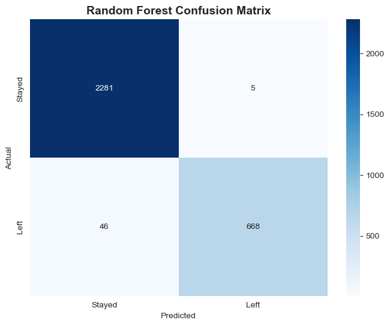

```
True Negatives:  2,281
False Positives: 5
False Negatives: 46
True Positives:  668
```

```python
# Confusion Matrix for Random Forest
cm_rf = confusion_matrix(y_test, y_pred_rf)

plt.figure(figsize=(8, 6))
sns.heatmap(cm_rf, annot=True, fmt='d', cmap='Blues',
            xticklabels=['Stayed', 'Left'],
            yticklabels=['Stayed', 'Left'])
plt.title('Random Forest Confusion Matrix', fontsize=14, fontweight='bold')
plt.xlabel('Predicted')
plt.ylabel('Actual')
plt.show()

tn, fp, fn, tp = cm_rf.ravel()
print(f'True Negatives:  {tn:,}')
print(f'False Positives: {fp:,}')
print(f'False Negatives: {fn:,}')
print(f'True Positives:  {tp:,}')
```

**Random Forest Performance Analysis:**

[output not shown]

**Key Insights:**

### 6.4 XGBoost Classifier

```python
# XGBoost pipeline
xgb_pipeline = Pipeline([
    ('scaler', StandardScaler()),
    ('classifier', XGBClassifier(
        n_estimators=200,
        max_depth=10,
        learning_rate=0.1,
        random_state=42,
        use_label_encoder=False,
        eval_metric='logloss'
    ))
])

# Cross-validation
cv_scores_xgb = cross_val_score(xgb_pipeline, X_train, y_train, cv=cv, scoring='accuracy')

print('XGBoost Cross-Validation Results:')
print(f'  Mean accuracy: {cv_scores_xgb.mean():.4f}')
print(f'  Std accuracy: {cv_scores_xgb.std():.4f}')

# Train and evaluate on test set
xgb_pipeline.fit(X_train, y_train)
y_pred_xgb = xgb_pipeline.predict(X_test)
xgb_accuracy = accuracy_score(y_test, y_pred_xgb)

print(f'\nTest Accuracy: {xgb_accuracy:.4f}')
print('\nClassification Report:')
print(classification_report(y_test, y_pred_xgb))
```

```
XGBoost Cross-Validation Results:
  Mean accuracy: 0.9902
  Std accuracy: 0.0017

Test Accuracy: 0.9893

Classification Report:
              precision    recall  f1-score   support

           0       0.99      1.00      0.99      2286
           1       0.98      0.97      0.98       714

    accuracy                           0.99      3000
   macro avg       0.99      0.98      0.99      3000
weighted avg       0.99      0.99      0.99      3000
```

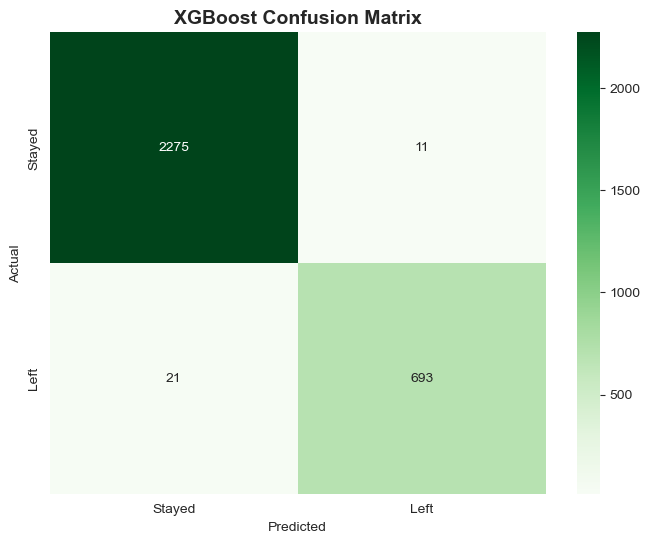

```
True Negatives:  2,275
False Positives: 11
False Negatives: 21
True Positives:  693
```

```python
# Confusion Matrix for XGBoost
cm_xgb = confusion_matrix(y_test, y_pred_xgb)

plt.figure(figsize=(8, 6))
sns.heatmap(cm_xgb, annot=True, fmt='d', cmap='Greens',
            xticklabels=['Stayed', 'Left'],
            yticklabels=['Stayed', 'Left'])
plt.title('XGBoost Confusion Matrix', fontsize=14, fontweight='bold')
plt.xlabel('Predicted')
plt.ylabel('Actual')
plt.show()

tn, fp, fn, tp = cm_xgb.ravel()
print(f'True Negatives:  {tn:,}')
print(f'False Positives: {fp:,}')
print(f'False Negatives: {fn:,}')
print(f'True Positives:  {tp:,}')
```

**XGBoost Performance Analysis:**

[output not shown]

**Key Insights:**

## 7. Model Evaluation and Comparison

### 7.1 Model Performance Comparison

```python
# Dictionary to store results
results = {
    'Model': ['Logistic Regression', 'Random Forest', 'XGBoost'],
    'Accuracy': [lr_accuracy, rf_accuracy, xgb_accuracy]
}

results_df = pd.DataFrame(results)
print(results_df)
```

```
                 Model  Accuracy
0  Logistic Regression  0.791667
1        Random Forest  0.983000
2              XGBoost  0.989333
```

### 7.2 ROC Curves Comparison

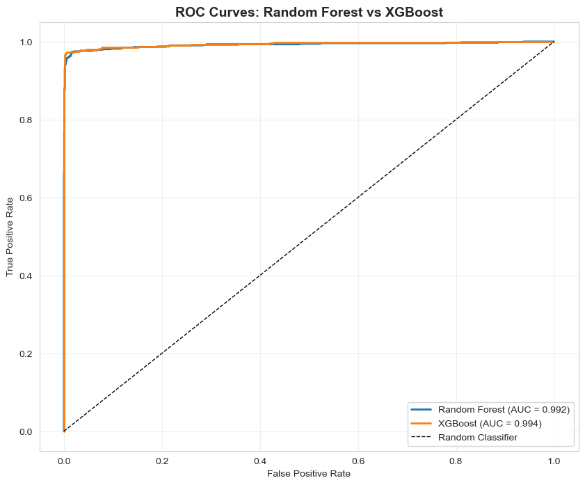

```python
# Get prediction probabilities
rf_proba = rf_pipeline.predict_proba(X_test)[:, 1]
xgb_proba = xgb_pipeline.predict_proba(X_test)[:, 1]

# Calculate ROC curves
rf_fpr, rf_tpr, _ = roc_curve(y_test, rf_proba)
xgb_fpr, xgb_tpr, _ = roc_curve(y_test, xgb_proba)

# Calculate AUC
rf_auc = roc_auc_score(y_test, rf_proba)
xgb_auc = roc_auc_score(y_test, xgb_proba)

# Plot ROC curves
plt.figure(figsize=(10, 8))
plt.plot(rf_fpr, rf_tpr, label=f'Random Forest (AUC = {rf_auc:.3f})', linewidth=2)
plt.plot(xgb_fpr, xgb_tpr, label=f'XGBoost (AUC = {xgb_auc:.3f})', linewidth=2)
plt.plot([0, 1], [0, 1], 'k--', label='Random Classifier', linewidth=1)
plt.xlabel('False Positive Rate')
plt.ylabel('True Positive Rate')
plt.title('ROC Curves: Random Forest vs XGBoost', fontsize=14, fontweight='bold')
plt.legend()
plt.grid(True, alpha=0.3)
plt.show()
```

## 8. Feature Importance Analysis

### 8.1 Feature Importance from Random Forest

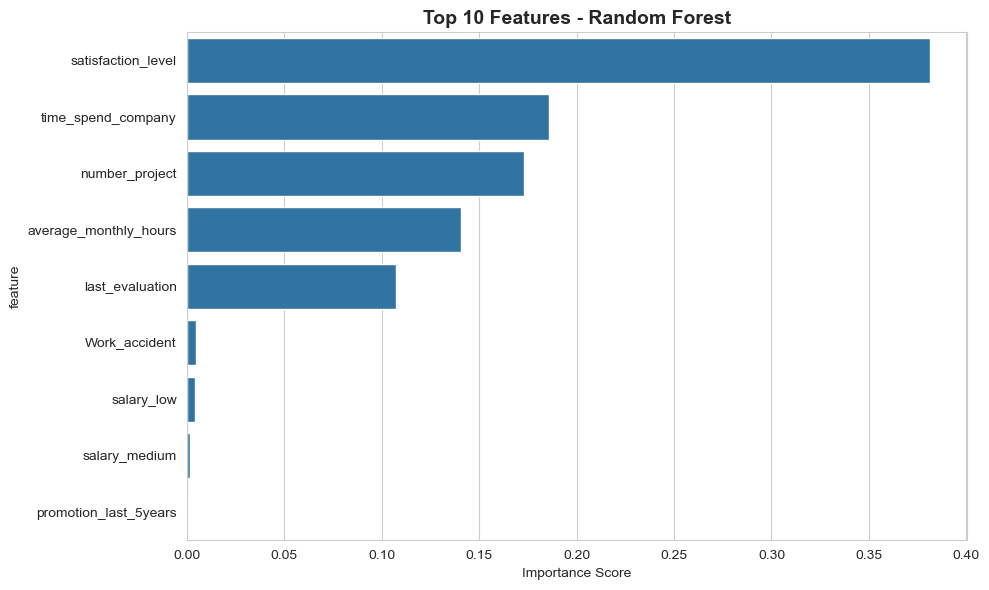

```
Top 5 Features (Random Forest):
              feature  importance
   satisfaction_level    0.381375
   time_spend_company    0.185884
       number_project    0.173245
average_monthly_hours    0.140767
      last_evaluation    0.107557
```

```python
# Get feature importance from Random Forest
rf_model = rf_pipeline.named_steps['classifier']
feature_names = X.columns
rf_importance = rf_model.feature_importances_

# Create dataframe
rf_feature_importance = pd.DataFrame({
    'feature': feature_names,
    'importance': rf_importance
}).sort_values('importance', ascending=False)

# Plot
plt.figure(figsize=(10, 6))
sns.barplot(data=rf_feature_importance.head(10), x='importance', y='feature')
plt.title('Top 10 Features - Random Forest', fontsize=14, fontweight='bold')
plt.xlabel('Importance Score')
plt.tight_layout()
plt.show()

print('\nTop 5 Features (Random Forest):')
print(rf_feature_importance.head(5).to_string(index=False))
```

### 8.2 Feature Importance from XGBoost

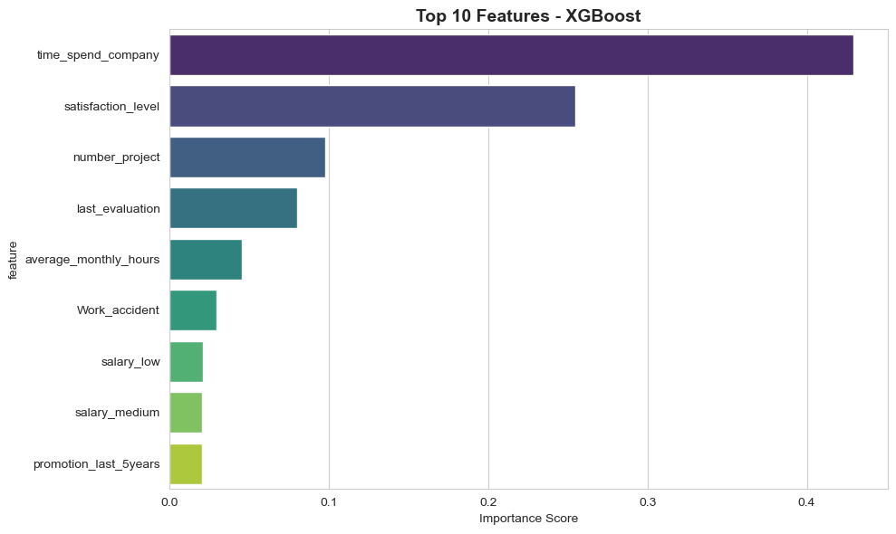

```
Top 5 Features (XGBoost):
              feature  importance
   time_spend_company    0.429356
   satisfaction_level    0.255022
       number_project    0.097970
      last_evaluation    0.080088
average_monthly_hours    0.045579
```

```python
# Get feature importance from XGBoost
xgb_model = xgb_pipeline.named_steps['classifier']
xgb_importance = xgb_model.feature_importances_

# Create dataframe
xgb_feature_importance = pd.DataFrame({
    'feature': feature_names,
    'importance': xgb_importance
}).sort_values('importance', ascending=False)

# Plot
plt.figure(figsize=(10, 6))
colors = sns.color_palette('viridis', len(xgb_feature_importance.head(10)))
sns.barplot(data=xgb_feature_importance.head(10), x='importance', y='feature', palette=colors)
plt.title('Top 10 Features - XGBoost', fontsize=14, fontweight='bold')
plt.xlabel('Importance Score')
plt.tight_layout()
plt.show()

print('\nTop 5 Features (XGBoost):')
print(xgb_feature_importance.head(5).to_string(index=False))
```

## 9. Business Recommendations

### 9.1 Risk Segmentation Framework

#### 🟢 LOW RISK (0-30% probability)

- **Profile**: High satisfaction (>0.65), 3-4 projects, promoted recently, medium/high salary
- **Action**: Regular engagement, development plans, quarterly check-ins

#### 🟡 MEDIUM RISK (30-70% probability)

- **Profile**: Medium satisfaction (0.45-0.65), 4-5 projects, 2-4 years tenure, no recent promotion
- **Action**: Stay interviews, career discussions, workload check, 30-day action plan

#### 🔴 HIGH RISK (70%+ probability)

- **Profile**: Low satisfaction (<0.45), 6+ projects, 3-5 years tenure, low salary, no promotion
- **Action**: IMMEDIATE intervention, manager discussion, retention bonus, role change consideration

### 9.2 Short-Term Actions

1. **Targeted Retention Program**
   - Identify employees with satisfaction < 0.5
   - Conduct stay interviews within 2 weeks
   - Address specific concerns raised
   - Assign mentors for at-risk employees
2. **Workload Management**
   - Monitor employees with 6+ projects
   - Redistribute work among team members
   - Implement "no overtime" policy for overworked staff
   - Regular check-ins on work-life balance
3. **Recognition & Feedback Culture**
   - Implement consistent recognition programs
   - Create real-time feedback loops
   - Boost morale through appreciation
   - Signal long-term investment in employee growth

### 9.3 Long-Term Strategies

1. **Career Development Path**
   - Create clear promotion criteria
   - Quarterly career discussions with managers
   - Skill development programs and certifications
   - Internal job rotation opportunities
2. **Compensation Review**
   - Annual salary benchmarking against market
   - Performance-based incentives and bonuses
   - Retention bonuses for key talent at 3-5 year mark
   - Transparent salary bands and growth path
3. **Improved Onboarding**
   - Strengthen 0-1 year employee experience
   - Structured onboarding programs
   - Early engagement activities
   - Mentor assignment from day one

### 9.4 Implementation Roadmap

| Timeline | Action |
| --- | --- |
| Month 1 | Deploy model & identify at-risk employees |
| Month 2 | Begin targeted interventions with HRBPs |
| Month 3 | Track progress & adjust strategies |
| Month 6 | Measure impact & refine approach |
| Year 1 | Full program rollout across organization |

## 10. Conclusion and Next Steps

### 10.3 Business Value

| Metric | Target |
| --- | --- |
| Potential annual savings | $2M+ |
| Turnover reduction target | 30% |
| ROI timeline | 6-12 months |
| Employee satisfaction improvement | 15-20% |

```python
# Save the final model
import joblib

# Save the pipeline
joblib.dump(rf_pipeline, 'employee_retention_best_model.pkl')
print('✅ Model saved as employee_retention_best_model.pkl')

# Save feature names for reference
with open('model_features.txt', 'w') as f:
    for feature in X.columns:
        f.write(f"{feature}\n")
print('✅ Feature list saved as model_features.txt')

print('\n📊 Project completed successfully!')
```

```
✅ Model saved as employee_retention_best_model.pkl
✅ Feature list saved as model_features.txt

📊 Project completed successfully!
```